# Data Analysis with Friends (part 2)

### November 5, 2014

This is data from [FiveThirtyEight's article on picking a college major](http://fivethirtyeight.com/features/the-economic-guide-to-picking-a-college-major/). All data is from American Community Survey 2010-2012 [Public Use Microdata Series](http://www.census.gov/acs/www/data_documentation/pums_documentation/). We will look at details on graduate school attendees

```python
library(bitops)
library(RCurl)
library(plyr)
library(dplyr)
library(reshape2)
library(tidyr)
library(ggplot2)
```

```python
grad_data <- read.csv(text=getURL("https://raw.githubusercontent.com/fivethirtyeight/data/master/college-majors/grad-students.csv"))
head(grad_data)
#table(grad_data$Major_category)
```

```
  Major_code                                  Major
1       5601                  CONSTRUCTION SERVICES
2       6004      COMMERCIAL ART AND GRAPHIC DESIGN
3       6211                 HOSPITALITY MANAGEMENT
4       2201 COSMETOLOGY SERVICES AND CULINARY ARTS
5       2001             COMMUNICATION TECHNOLOGIES
6       3201                        COURT REPORTING
                       Major_category Grad_total Grad_sample_size Grad_employed
1 Industrial Arts & Consumer Services       9173              200          7098
2                                Arts      53864              882         40492
3                            Business      24417              437         18368
4 Industrial Arts & Consumer Services       5411               72          3590
5             Computers & Mathematics       9109              171          7512
6                 Law & Public Policy       1542               22          1008
  Grad_full_time_year_round Grad_unemployed Grad_unemployment_rate Grad_median
```

[output cut: 27 more lines]

Here are some questions to get us started as a rough guide.

1. Explore Graduate student unemployment (Grad_unemployment_rate) as a function of Major/Major_category.

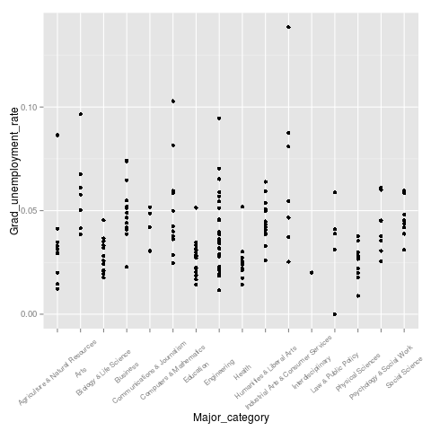

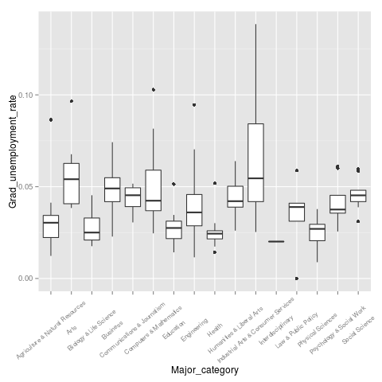

```python
####
#Topic: 1
#Owner:
#Participants: Ian/joy
####


qplot(data=grad_data,x= Major_category ,y=Grad_unemployment_rate)+ theme( axis.text.x  = element_text(angle=40, vjust=0.5, size=8))


qplot(data=grad_data,x= Major_category ,y=Grad_unemployment_rate,geom='boxplot')+ theme( axis.text.x  = element_text(angle=40, vjust=0.5, size=8))
```

```python
smmry = ddply(grad_data, .(Major_category), summarize,
      min_unemp =  min(Grad_unemployment_rate,na.rm=T),
      mean_unemp = mean(Grad_unemployment_rate,na.rm = T),
      max_unemp = max(Grad_unemployment_rate,na.rm=T))

tmp = merge(grad_data[,c('Major_category','Grad_unemployment_rate','Major')],
            smmry[,c('Major_category','min_unemp')], by.x = c('Major_category','Grad_unemployment_rate'),
            by.y = c('Major_category','min_unemp'))

names(tmp)[3] = 'MinUnempMajor'

tmp2 = merge(grad_data[,c('Major_category','Grad_unemployment_rate','Major')],
            smmry[,c('Major_category','max_unemp')], by.x = c('Major_category','Grad_unemployment_rate'), by.y = c('Major_category','max_unemp'))

names(tmp2)[3] = 'MaxUnempMajor'

tmp3 = merge(tmp[,c(1,3)], tmp2[,c(1,3)])

for(i in 1:16){
cat(paste(tmp3[i,1],'\nHighest unemployment is in',tmp3[i,3],'\nLowest unemployment is in',tmp3[i,2],'\n\n'))}
```

```
Agriculture & Natural Resources
Highest unemployment is in MISCELLANEOUS AGRICULTURE
Lowest unemployment is in ANIMAL SCIENCES

Arts
Highest unemployment is in FILM VIDEO AND PHOTOGRAPHIC ARTS
Lowest unemployment is in VISUAL AND PERFORMING ARTS

Biology & Life Science
Highest unemployment is in COGNITIVE SCIENCE AND BIOPSYCHOLOGY
Lowest unemployment is in NEUROSCIENCE

Business
Highest unemployment is in ACTUARIAL SCIENCE
Lowest unemployment is in OPERATIONS LOGISTICS AND E-COMMERCE

Communications & Journalism
Highest unemployment is in MASS MEDIA
Lowest unemployment is in ADVERTISING AND PUBLIC RELATIONS

Computers & Mathematics
Highest unemployment is in MATHEMATICS AND COMPUTER SCIENCE
Lowest unemployment is in COMPUTER PROGRAMMING AND DATA PROCESSING

Education
Highest unemployment is in SCHOOL STUDENT COUNSELING
Lowest unemployment is in MATHEMATICS TEACHER EDUCATION

Engineering
Highest unemployment is in ENGINEERING AND INDUSTRIAL MANAGEMENT
Lowest unemployment is in NUCLEAR ENGINEERING

Health
Highest unemployment is in HEALTH AND MEDICAL ADMINISTRATIVE SERVICES
Lowest unemployment is in COMMUNICATION DISORDERS SCIENCES AND SERVICES

Humanities & Liberal Arts
Highest unemployment is in INTERCULTURAL AND INTERNATIONAL STUDIES
Lowest unemployment is in UNITED STATES HISTORY

```

[output cut: 8 more lines]

```
Law & Public Policy
Highest unemployment is in PUBLIC ADMINISTRATION
Lowest unemployment is in COURT REPORTING

Physical Sciences
Highest unemployment is in PHYSICAL SCIENCES
Lowest unemployment is in NUCLEAR, INDUSTRIAL RADIOLOGY, AND BIOLOGICAL TECHNOLOGIES

Psychology & Social Work
Highest unemployment is in SOCIAL PSYCHOLOGY
Lowest unemployment is in EDUCATIONAL PSYCHOLOGY

Social Science
Highest unemployment is in INTERDISCIPLINARY SOCIAL SCIENCES
Lowest unemployment is in GEOGRAPHY
```

2. Is there any trend in full-time vs. part time employment with regards to major or major category.

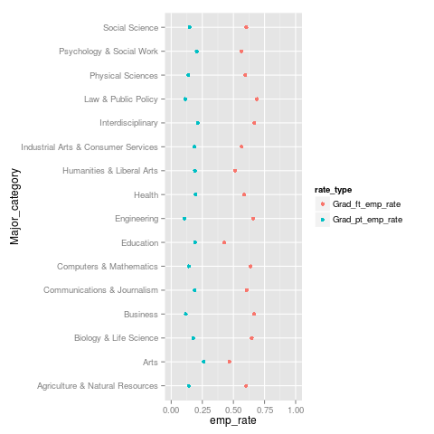

```
Error in mutate_impl(.data, dots): attempt to use zero-length variable name
```

```python
####
#Topic: 2
#Owner:
#Participants: Ian Lyttle
####


# grad_data %>% summary()

tmp <-
  grad_data %>%
  group_by(Major_category) %>%
  summarise(
    Grad_ft_emp_rate = sum(Grad_full_time_year_round) / sum(Grad_total),
    Grad_pt_emp_rate = sum(Grad_employed - Grad_full_time_year_round) / sum(Grad_total)
  ) %>%
  gather(key = rate_type, value = emp_rate, -Major_category)


 qplot(emp_rate, Major_category, colour = rate_type, data = tmp)  + xlim(0, 1)

 tmp2 <-
  grad_data %>%
  mutate(
    Grad_ft_emp_rate = Grad_full_time_year_round / Grad_total,

  )
```

3. Are there any majors/major categories that pay differently for grad vs. undergrad (Nongrad)? Are there any that don't?

```python
####
#Topic: 3
#Owner: Andee and Joe
#Participants: G
####
```

[output not shown]

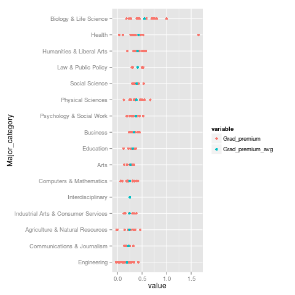

```python
tmp <- grad_data %>%
  select(Major, Major_category, Grad_premium) %>%
  left_join(grad_data %>% group_by(Major_category) %>% summarise(Grad_premium_avg = mean(Grad_premium)))

tmp$Major_category <- factor(tmp$Major_category, levels= tmp$Major_category[order(tmp$Grad_premium_avg)])


tmp.m <- melt(tmp, id.vars="Major_category", measure.vars=c("Grad_premium", "Grad_premium_avg"))



ggplot(tmp.m) +
geom_point(aes(x=value, y=Major_category, colour=variable))
```

4. How does statistics (Statistics and Decision Science) compare to the other majors in its category? In general?

```python
####
#Topic: 4
#Owner: Sam Tyner
#Participants:
####
stat <- filter(grad_data, Major == "STATISTICS AND DECISION SCIENCE")

comp_math <- filter(grad_data, Major_category == "Computers & Mathematics")

comp_math$Major <- c("Comm.Tech", "Comp.Prog & Data Proc.", "Comp.Net & Telecom", "Comp.Admin & Secure", "Comp & Info.Sys",
                     "Info.Sci", "Comp.Sci", "Math & Comp.Sci", "App.Math", "Stat", "Math")
```

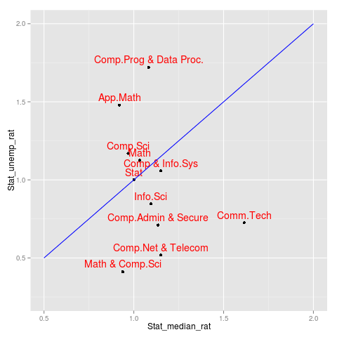

```python
comp_math$Stat_unemp_rat <- stat$Grad_unemployment_rate / comp_math$Grad_unemployment_rate
comp_math$Stat_median_rat <- stat$Grad_median / comp_math$Grad_median

ggplot(data = comp_math, aes(x = Stat_median_rat, y = Stat_unemp_rat)) + geom_point() +
 geom_text(aes(x = Stat_median_rat, y = .05+ Stat_unemp_rat, label = Major), color = 'red') +
  stat_function(fun = 'identity', color = 'blue') + xlim(c(0.5,2)) + ylim(c(.25,2))
```

```
geom_smooth: method="auto" and size of largest group is <1000, so using loess. Use 'method = x' to change the smoothing method.
```

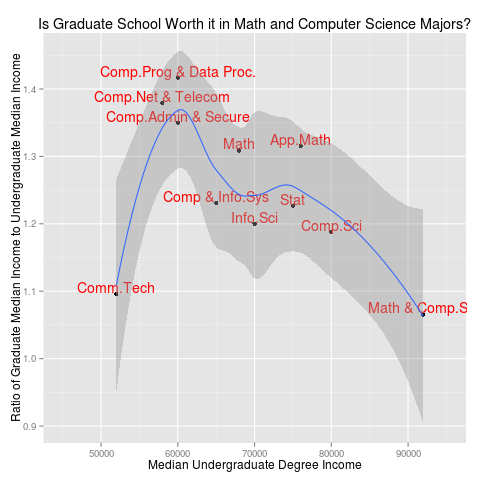

```python
ggplot(data = comp_math, aes(x = Nongrad_median, y = Grad_median/Nongrad_median)) + geom_point() +
 geom_text(aes(x = Nongrad_median, y = .01+ Grad_median/Nongrad_median, label = Major), color = 'red') +
   geom_smooth() + xlim(c(45000,95000)) + labs(x = "Median Undergraduate Degree Income", y = "Ratio of Graduate Median Income to Undergraduate Median Income", title = "Is Graduate School Worth it in Math and Computer Science Majors?")
```

What's the most popular grad major? non-grad? Is there a grad major that is relatively grad-heavy?

```python
####
#Topic: 5
#Owner: Eric Hare
#Participants:
####
```

```python
# Eric
#head(grad_data)
arrange(grad_data, desc(Grad_total))[1,"Major"] #Psych
arrange(grad_data, desc(Nongrad_total))[1,"Major"] #Business management
```

```
[1] PSYCHOLOGY
173 Levels: ACCOUNTING ACTUARIAL SCIENCE ... ZOOLOGY
```

```
[1] BUSINESS MANAGEMENT AND ADMINISTRATION
173 Levels: ACCOUNTING ACTUARIAL SCIENCE ... ZOOLOGY
```

```python
relative_major <- grad_data %>% mutate(Relative = Grad_total / Nongrad_total) %>% arrange(desc(Relative))
head(relative_major[,c("Major", "Relative")])
```

```
                                          Major  Relative
1    EDUCATIONAL ADMINISTRATION AND SUPERVISION 13.529603
2                     SCHOOL STUDENT COUNSELING  8.889337
3       HEALTH AND MEDICAL PREPARATORY PROGRAMS  4.368199
4                           CLINICAL PSYCHOLOGY  3.484584
5                         COUNSELING PSYCHOLOGY  3.087539
6 COMMUNICATION DISORDERS SCIENCES AND SERVICES  3.064398
```

```python
relative_major <- grad_data %>% mutate(Relative = Grad_total / Nongrad_total) %>% arrange(Relative)
head(relative_major[,c("Major", "Relative")])
```

```
                                   Major  Relative
1                  CONSTRUCTION SERVICES 0.1065859
2      COMMERCIAL ART AND GRAPHIC DESIGN 0.1165945
3                 HOSPITALITY MANAGEMENT 0.1361530
4 COSMETOLOGY SERVICES AND CULINARY ARTS 0.1440053
5             COMMUNICATION TECHNOLOGIES 0.1692525
6                        COURT REPORTING 0.1728506
```

6. Do people get a graduate degree in a major that will increase their earnings?

```
 [1] "Major_code"                   "Major"
 [3] "Major_category"               "Grad_total"
 [5] "Grad_sample_size"             "Grad_employed"
 [7] "Grad_full_time_year_round"    "Grad_unemployed"
 [9] "Grad_unemployment_rate"       "Grad_median"
[11] "Grad_P25"                     "Grad_P75"
[13] "Nongrad_total"                "Nongrad_employed"
[15] "Nongrad_full_time_year_round" "Nongrad_unemployed"
[17] "Nongrad_unemployment_rate"    "Nongrad_median"
[19] "Nongrad_P25"                  "Nongrad_P75"
[21] "Grad_share"                   "Grad_premium"
```

```
[1] 173
```

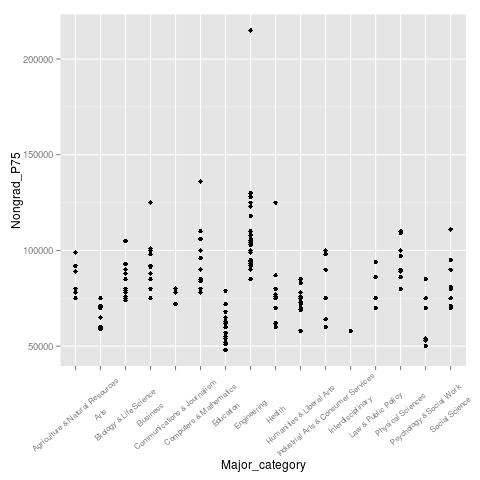

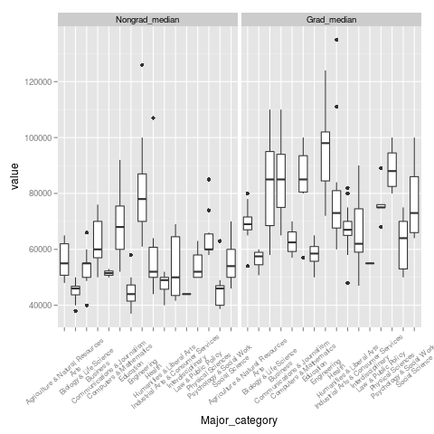

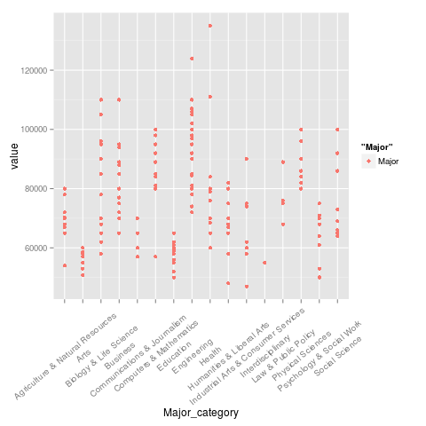

```python
####
#Topic: 6
#Owner:
#Participants: Guillermo, Natalia, Lindsay, Mengjia
####

names(grad_data)

with(grad_data,length(Major_category))

qplot(data=grad_data,x= Major_category ,y=Nongrad_P75)+ theme( axis.text.x  = element_text(angle=40, vjust=0.5, size=8))
dat_aux <- grad_data[,c("Major_category","Nongrad_median","Grad_median")]
aux <- melt(dat_aux[,-4])
qplot(data=aux,x= Major_category ,y=value,facets=~variable,geom="boxplot")+ theme( axis.text.x  = element_text(angle=40, vjust=0.5, size=8))

dat_aux <- grad_data[,c("Major","Major_category","Nongrad_median","Grad_median")]
dat_aux$diff<-with(dat_aux,Grad_median-Nongrad_median)
aux2 <- melt(dat_aux[,c(1:2,4)])
qplot(data=aux2,x= Major_category ,y=value,colour="Major")+ theme( axis.text.x  = element_text(angle=40, vjust=0.5, size=10))
```

7. What else do you want to explore?

```python
####
#Topic: A cat is nice, too.
#Owner: Can anyone really be said to "own" a cat?
#Participants:
####
```

Reshaping the data a bit first

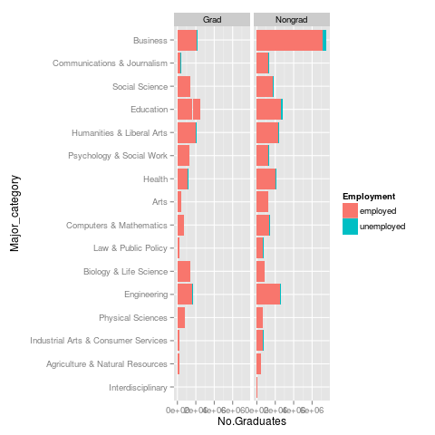

```python
# Topic: Reshaping the data
# Owner: Heike

require(reshape2)
gdm <- melt(grad_data, measure.var=c(6,8,14,16))
gdm$Status <- gsub("([^_]*)_.*", "\\1", as.character(gdm$variable))
names(gdm)[20] <- "No.Graduates"
gdm$Employment <- gsub("[^_]*_(.*)", "\\1", as.character(gdm$variable))

gdm$Major_category <- reorder(gdm$Major_category, gdm$No.Graduates)
qplot(Major_category, y=No.Graduates, data=gdm, fill=Employment, stat="identity", geom="bar", facets=~Status) + coord_flip()
```

```
  Major_code                                  Major
1       5601                  CONSTRUCTION SERVICES
2       6004      COMMERCIAL ART AND GRAPHIC DESIGN
3       6211                 HOSPITALITY MANAGEMENT
4       2201 COSMETOLOGY SERVICES AND CULINARY ARTS
5       2001             COMMUNICATION TECHNOLOGIES
6       3201                        COURT REPORTING
                       Major_category Grad_total Grad_sample_size Grad_employed
1 Industrial Arts & Consumer Services       9173              200          7098
2                                Arts      53864              882         40492
3                            Business      24417              437         18368
4 Industrial Arts & Consumer Services       5411               72          3590
5             Computers & Mathematics       9109              171          7512
6                 Law & Public Policy       1542               22          1008
  Grad_full_time_year_round Grad_unemployed Grad_unemployment_rate Grad_median
```

[output cut: 27 more lines]

```
    Agriculture & Natural Resources                                Arts
                                 10                                   8
             Biology & Life Science                            Business
                                 14                                  13
        Communications & Journalism             Computers & Mathematics
                                  4                                  11
                          Education                         Engineering
                                 16                                  29
                             Health           Humanities & Liberal Arts
                                 12                                  15
Industrial Arts & Consumer Services                   Interdisciplinary
                                  7                                   1
                Law & Public Policy                   Physical Sciences
                                  5                                  10
           Psychology & Social Work                      Social Science
                                  9                                   9
```

```
stat_bin: binwidth defaulted to range/30. Use 'binwidth = x' to adjust this.
```

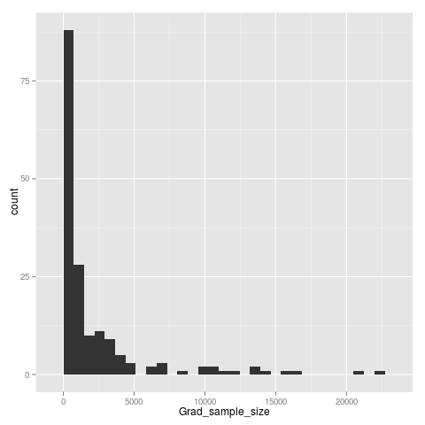

[figure not shown]

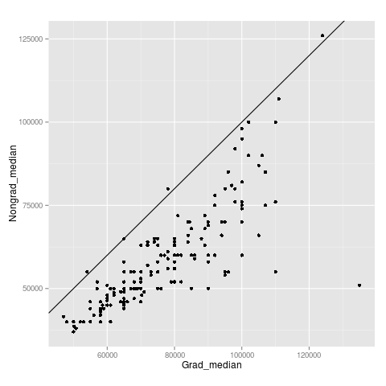

```
[1] HEALTH AND MEDICAL PREPARATORY PROGRAMS
[2] PETROLEUM ENGINEERING
[3] PHARMACY PHARMACEUTICAL SCIENCES AND ADMINISTRATION
[4] ACTUARIAL SCIENCE
[5] NUCLEAR ENGINEERING
[6] ZOOLOGY
173 Levels: COSMETOLOGY SERVICES AND CULINARY ARTS ...
```

```python
# Topic: Playground
# Owner: Di

head(grad_data)
table(grad_data$Major_category)
#qplot(Grad_sample_size, Major, data=grad_data)
qplot(Grad_sample_size, data=grad_data)
grad_data_di <- grad_data
grad_data_di$Major <- factor(grad_data_di$Major,
                             levels=grad_data_di$Major[order(grad_data_di$Grad_median)])
ggplot(data=grad_data_di) + geom_errorbar(aes(x=Major, ymin=Grad_P25, ymax=Grad_P75)) +
  geom_point(aes(x=Major, y=Grad_median)) + coord_flip()
qplot(Grad_median, Nongrad_median, data=grad_data_di) +
  geom_abline(intercept=0, slope=1) + theme(aspect.ratio=1)
head(grad_data_di$Major[order(grad_data_di$Grad_median, decreasing=T)])
```

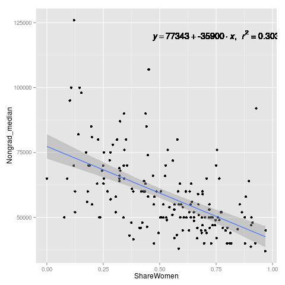

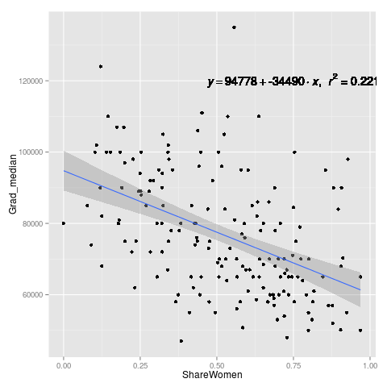

```python
####
#Topic: A cat is nice, too.
#Owner: Carson
#Participants: Sam H
####

recent_grad <- read.csv(text=getURL("https://raw.githubusercontent.com/fivethirtyeight/data/master/college-majors/recent-grads.csv"))
grads <- merge(grad_data, recent_grad, by = "Major_code", all.x = TRUE)

names(grads) <- sub("ShareWomen", "x", names(grads))
names(grads) <- sub("Nongrad_median", "y", names(grads))
names(grads) <- sub("Grad_median", "y2", names(grads))

p <- qplot(x, y, data = grads) + geom_smooth(method = "lm")

p2 <- qplot(x, y2, data = grads) + geom_smooth(method = "lm")


# http://stackoverflow.com/questions/7549694/ggplot2-adding-regression-line-equation-and-r2-on-graph
lm_eqn = function(df){
  m = lm(y ~ x, df);
  eq <- substitute(italic(y) == a + b %.% italic(x)*","~~italic(r)^2~"="~r2,
                   list(a = format(coef(m)[1], digits = 2),
                        b = format(coef(m)[2], digits = 2),
                        r2 = format(summary(m)$r.squared, digits = 3)))
  as.character(as.expression(eq));
}

lm_eqn2 = function(df){
  m = lm(y2 ~ x, df);
  eq <- substitute(italic(y) == a + b %.% italic(x)*","~~italic(r)^2~"="~r2,
                   list(a = format(coef(m)[1], digits = 2),
                        b = format(coef(m)[2], digits = 2),
                        r2 = format(summary(m)$r.squared, digits = 3)))
  as.character(as.expression(eq));
}

p + geom_text(aes(x = 0.75, y = 120000, label = lm_eqn(grads)), parse = TRUE) +
  xlab("ShareWomen") + ylab("Nongrad_median")

p2 + geom_text(aes(x = 0.75, y = 120000, label = lm_eqn2(grads)), parse = TRUE) +
  xlab("ShareWomen") + ylab("Grad_median")
```

```python
####
#Topic: The cost of dropping out
#Owner: Alex
#Participants: Barack Obama
####


results = grad_data %>%
  group_by(Major_category) %>%
  summarise(med_grad_median = median(Grad_median), med_nongrad_median = median(Nongrad_median)) %>%
  mutate(grad_diff = med_grad_median - med_nongrad_median) %>%
  arrange(desc(grad_diff))
results2 = results[,c(-2, -3)]
print(results2)
```

```
Source: local data frame [16 x 2]

                        Major_category grad_diff
1               Biology & Life Science     30000
2                    Physical Sciences     28000
3                             Business     25000
4                  Law & Public Policy     23000
5                               Health     21000
6                          Engineering     20000
7                       Social Science     19000
8            Humanities & Liberal Arts     18000
9             Psychology & Social Work     18000
10             Computers & Mathematics     17000
11                           Education     14500
12     Agriculture & Natural Resources     14000
13 Industrial Arts & Consumer Services     12000
14                                Arts     11500
15         Communications & Journalism     11000
16                   Interdisciplinary     11000
```